# Introduction to sensiPhy

Gustavo Paterno; Caterine Penone; Gijsbert Werner

2017-01-06

The **sensiPhy** package provides simple functions to perform sensitivity analysis in phylogenetic comparative methods. It uses several simulation methods to estimate the impact of different types of uncertainty on PGLS models:

1. Sampling uncertainty (sample size; influential species and clades)
2. Phylogenetic uncertainty
3. Data uncertainty (intraspecific variation and measurement error)

sensiPhy functions use a common syntax that combines the type of uncertainty and the type of model: *uncertainty.type_phylm* (for linear regressions) or *uncertainty.type_phyglm* (for logistic regressions).  
Mandatory arguments of sensiPhy functions include: `function(formula , data, phy, ...)`

The following examples describes the basic usage of **sensiPhy** functions.

Loading the package and data

```r
set.seed(12345)
library(sensiPhy)

### Loading data:
data(alien)
data(primates) # se ?alien & ?primates for details about the data.
```

## 1.Sampling uncertainty:

#### Sensitivity analysis for sampling size:

The `samp_phylm` function performs analyses of sensitivity to species sampling by randomly removing species and detecting the effects on parameter estimates in a phylogenetic linear regression.

- Additional arguments:  
  **breaks:** A vector containing the percentages of species to remove  
  **times:** The number of times species are randomly deleted for each break

```r
# run analysis:
samp <- samp_phylm(log(gestaLen) ~ log(adultMass), phy = alien$phy[[1]],
                   data = alien$data, times = 10, track = F)
```

```
## Used dataset has  84  species that match data and phylogeny
```

```r
# You can change the number of repetitions and break intervals:
samp2 <- samp_phylm(log(gestaLen) ~ log(adultMass), phy = alien$phy[[1]], track = F,
                    data = alien$data, times = 10, breaks = c(0.1, 0.2, 0.3, 0.4))
```

```
## Used dataset has  84  species that match data and phylogeny
```

```r
# You can change the phylogenetic model:
samp <- samp_phylm(log(gestaLen) ~ log(adultMass), phy = alien$phy[[1]],
                   data = alien$data, model = "kappa", track = F)
```

```
## Used dataset has  84  species that match data and phylogeny
```

```r
# Check results:
knitr::kable(summary(samp))
```

```
## 150 simulations saved, see output$samp.model.estimates to acess all simulations
```

| % Species Removed | % Significant Intercepts | Mean Intercept Change (%) | Mean sDFintercept | % Significant Slopes | Mean Slope Change (%) | Mean sDFslope |
| --- | --- | --- | --- | --- | --- | --- |
| 10 | 100 | 2.283333 | -0.0693129 | 100 | 4.030000 | 0.1612823 |
| 20 | 100 | 4.126667 | -0.0461733 | 100 | 6.693333 | 0.3821512 |
| 30 | 100 | 5.880000 | -0.4097442 | 100 | 11.643333 | 0.7037473 |
| 40 | 100 | 7.023333 | -0.1710145 | 100 | 17.770000 | 0.9678550 |
| 50 | 100 | 8.073333 | -0.0125137 | 100 | 13.436667 | 0.7282428 |

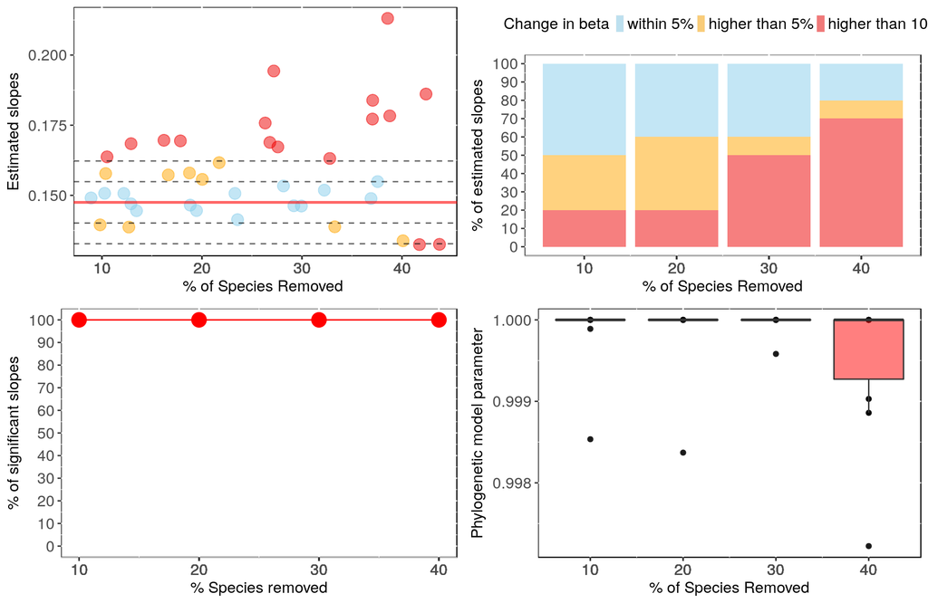

```r
# Visual diagnostics
sensi_plot(samp2)
```

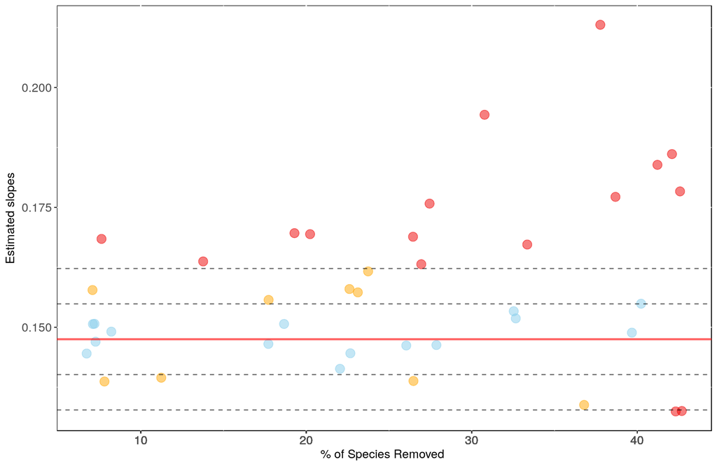

```r
# You can specify which graph and parameter ("slope" or "intercept") to print:
sensi_plot(samp2, graphs = 1)
```

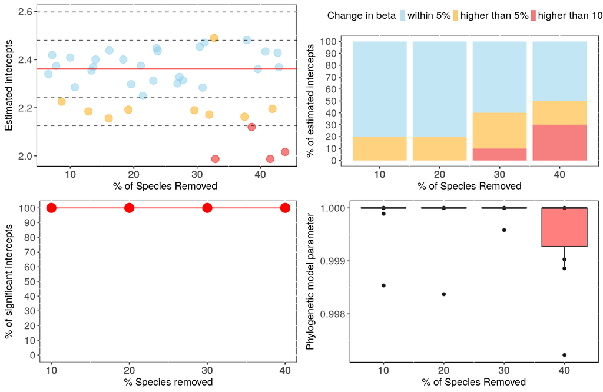

```r
sensi_plot(samp2, param = "intercept")
```

#### Sensitivity analysis for influential species:

The function `influ_phylm` performs leave-one-out deletion analyis for phylogenetic linear regression, and detects influential species.

```r
# run analysis:
influ <- influ_phylm(log(gestaLen) ~ log(adultMass), phy = alien$phy[[1]],
                     data = alien$data, track = F)
```

```
## Used dataset has  84  species that match data and phylogeny
```

```r
# To check summary results:
summary(influ)
```

```
## $`Influential species for the Slope`
## [1] "Ovis_ammon"         "Ovis_aries"         "Equus_hemionus"
## [4] "Camelus_bactrianus" "Axis_porcinus"      "Axis_axis"
##
## $`Slope Estimates`
##      Species removed     Slope      DFslope Change(%)         Pval
## 1         Ovis_ammon 0.1585335  0.011033226       7.5 1.465612e-10
## 2         Ovis_aries 0.1567383  0.009238004       6.3 2.949203e-10
## 3     Equus_hemionus 0.1384028 -0.009097490       6.2 3.326380e-09
## 4 Camelus_bactrianus 0.1400746 -0.007425680       5.0 2.741126e-09
## 5      Axis_porcinus 0.1546280  0.007127723       4.8 3.792296e-10
## 6          Axis_axis 0.1531949  0.005694542       3.9 4.646006e-10
##
## $`Influential species for the Intercept`
## [1] "Ornithorhynchus_anatinus" "Ovis_ammon"
## [3] "Ovis_aries"               "Axis_porcinus"
## [5] "Sorex_cinereus"
##
## $`Intercept Estimates`
##            Species removed Intercept DFintercept Change(%)         Pval
## 1 Ornithorhynchus_anatinus  2.459667  0.09744173       4.1 4.298004e-10
## 2               Ovis_ammon  2.275301 -0.08692386       3.7 2.181632e-09
## 3               Ovis_aries  2.289397 -0.07282803       3.1 2.279349e-09
## 4            Axis_porcinus  2.306031 -0.05619439       2.4 1.890367e-09
## 5           Sorex_cinereus  2.412289  0.05006331       2.1 7.463555e-10
```

```r
# Most influential speciesL
influ$influential.species
```

```
## $influ.sp.slope
## [1] "Ovis_ammon"         "Ovis_aries"         "Equus_hemionus"
## [4] "Camelus_bactrianus" "Axis_porcinus"      "Axis_axis"
##
## $influ.sp.intercept
## [1] "Ornithorhynchus_anatinus" "Ovis_ammon"
## [3] "Ovis_aries"               "Axis_porcinus"
## [5] "Sorex_cinereus"
```

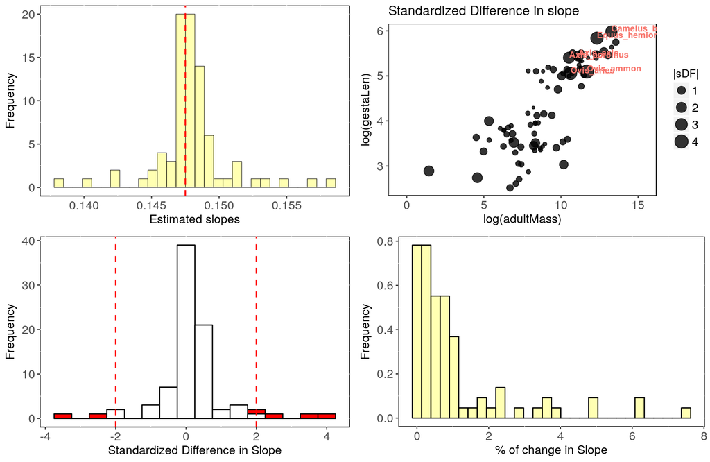

```r
# Visual diagnostics
sensi_plot(influ)
```

#### Sensitivity analysis for influential clades (Primates data):

The function `clade_phylm` estimate the impact on model estimates of phylogenetic linear regression after removing clades from the analysis.

- Additional arguments:  
  **clade.col:** The name of a column in the provided data frame with clades specification (a character vector with clade names).  
  **n.species:** Minimum number of species in the clade in order to include this clade in the leave-one-out deletion analyis. Default is 5.

```r
# run analysis:
clade <- clade_phylm(log(sexMaturity) ~ log(adultMass), phy = primates$phy[[1]],
                     data = primates$data, clade.col = "family", track = F)
```

```
## Used dataset has  95  species that match data and phylogeny
```

```r
# To check summary results and most influential clades:
knitr::kable(summary(clade))
```

|  | clade.removed | N.species | slope | DFslope | Change (%) | Pval | m.null.slope | p.randomization |
| --- | --- | --- | --- | --- | --- | --- | --- | --- |
| 3 | Cercopithecidae | 32 | 0.3075424 | 0.0570680 | 22.8 | 0e+00 | 0.2807358 | 0.15 |
| 2 | Cebidae | 19 | 0.2199214 | -0.0305530 | 12.2 | 7e-07 | 0.2663944 | 0.02 |
| 1 | Callitrichidae | 9 | 0.2260405 | -0.0244339 | 9.8 | 1e-07 | 0.2569219 | 0.00 |
| 4 | Lemuridae | 8 | 0.2581974 | 0.0077230 | 3.1 | 0e+00 | 0.2573712 | 0.45 |

|  | clade.removed | N.species | intercept | DFintercept | Change (%) | Pval | m.null.intercept | p.randomization |
| --- | --- | --- | --- | --- | --- | --- | --- | --- |
| 3 | Cercopithecidae | 32 | 4.496911 | -0.3891243 | 8.0 | 0e+00 | 4.650337 | 0.22 |
| 2 | Cebidae | 19 | 5.051216 | 0.1651806 | 3.4 | 7e-07 | 4.761465 | 0.04 |
| 1 | Callitrichidae | 9 | 5.072203 | 0.1861671 | 3.8 | 1e-07 | 4.837154 | 0.00 |
| 4 | Lemuridae | 8 | 4.829880 | -0.0561552 | 1.1 | 0e+00 | 4.830243 | 0.44 |

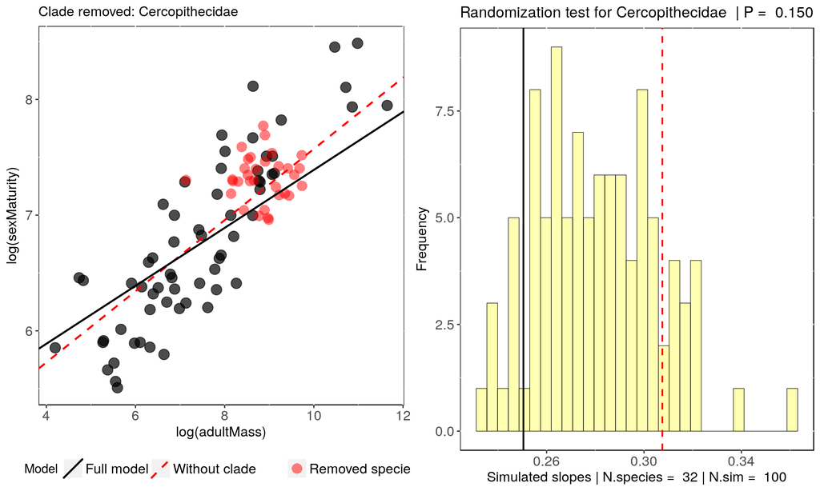

```r
# Visual diagnostics for clade removal:
sensi_plot(clade, "Cercopithecidae")
```

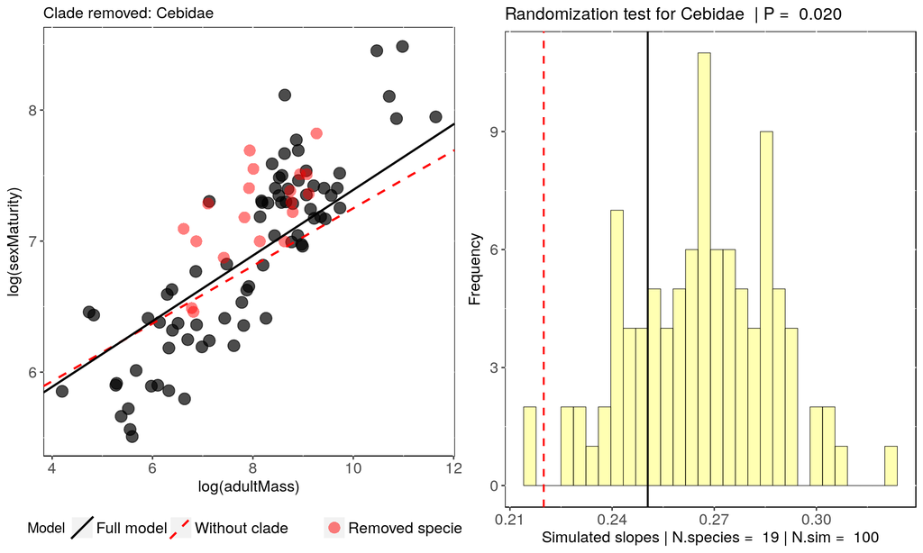

```r
sensi_plot(clade, "Cebidae")
```

## 2.Phylogenetic uncertainty:

The function `tree_phylm` performs Phylogenetic linear regression evaluating uncertainty in trees topology.

- Additional arguments:  
  **times:** Number of times to repeat the analysis with n different trees picked randomly in the multiPhylo file. If NULL, times = 2

#### Sensitivity analysis for phylogenetic trees:

```r
# This analysis needs a multiphylo file:
class(alien$phy)
```

```
## [1] "multiPhylo"
```

```r
alien$phy
```

```
## 101 phylogenetic trees
```

```r
# run PGLS accounting for phylogenetic uncertain:
tree <- tree_phylm(log(gestaLen) ~ log(adultMass), phy = alien$phy,
                   data = alien$data, times = 100, track = F)
```

```
## Used dataset has  84  species that match data and phylogeny
```

```r
# To check summary results:
knitr::kable(summary(tree))
```

|  | mean | CI_low | CI_high |
| --- | --- | --- | --- |
| intercept | 2.327 | 2.319 | 2.335 |
| se.intercept | 0.342 | 0.342 | 0.343 |
| pval.intercept | 0.000 | 0.000 | 0.000 |
| slope | 0.152 | 0.151 | 0.153 |
| se.slope | 0.022 | 0.022 | 0.022 |
| pval.slope | 0.000 | 0.000 | 0.000 |

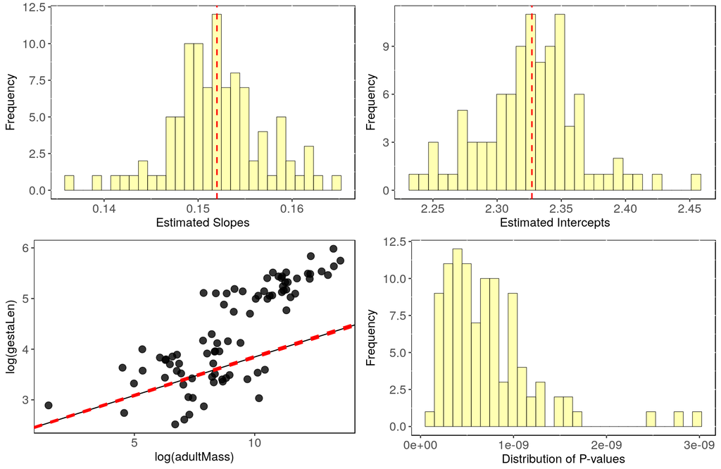

```r
# Visual diagnostics
sensi_plot(tree)
```

## 3.Data uncertainty:

The function `intra_phylm` performs Phylogenetic linear regression evaluating intraspecific variability.

- Additional arguments:  
  **Vy:** Name of the column containing the standard deviation or the standard error of the response variable. When information is not available for one taxon, the value can be 0 or NA.  
  **Vx:** Name of the column containing the standard deviation or the standard error of the predictor variable. When information is not available for one taxon, the value can be 0 or NA  
  **x.transf:** Transformation for the response variable (e.g. log or sqrt). Please use this argument instead of transforming data in the formula directly.  
  **y.transf:** Transformation for the predictor variable (e.g. log or sqrt). Please use this argument instead of transforming data in the formula directly.  
  **distrib:** A character string indicating which distribution to use to generate a random value for the response and/or predictor variables. Default is normal distribution: “normal” (function rnorm). Uniform distribution: “uniform” (runif) Warning: we recommend to use normal distribution with Vx or Vy = standard deviation of the mean.  
  **times:** Number of times to repeat the analysis with n different trees picked randomly in the multiPhylo file. If NULL, times = 2

#### Sensitivity analysis for intraspecific variation and measurement error:

```r
# run PGLS accounting for intraspecific variation:
intra <- intra_phylm(gestaLen ~ adultMass, phy = alien$phy[[1]], track = F,
                     data = alien$data, Vy = "SD_gesta", Vx = "SD_mass",
                     times = 100, x.transf = log, y.transf = log)
```

```
## Used dataset has  84  species that match data and phylogeny
```

```r
# To check summary results:
knitr::kable(summary(intra))
```

|  | mean | CI_low | CI_high |
| --- | --- | --- | --- |
| intercept | 2.417 | 2.383 | 2.451 |
| se.intercept | 0.374 | 0.370 | 0.379 |
| pval.intercept | 0.000 | 0.000 | 0.000 |
| slope | 0.140 | 0.136 | 0.144 |
| se.slope | 0.023 | 0.023 | 0.023 |
| pval.slope | 0.000 | 0.000 | 0.000 |

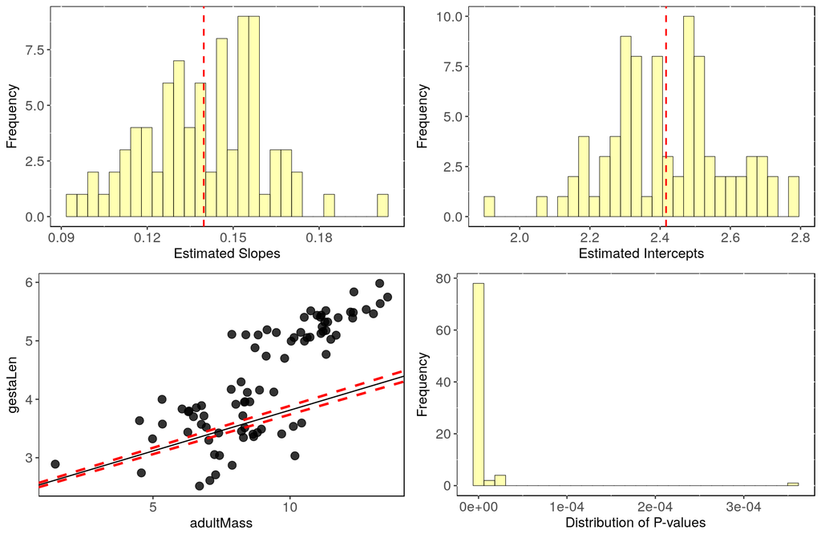

```r
# Visual diagnostics
sensi_plot(intra)
```